# high-dim-examples.Rmd

Load some packages we need

```r
library(Biobase)
library(limma)
library(broom)
library(genefilter)
library(qvalue)
```

## Download the data

```r
con =url("http://bowtie-bio.sourceforge.net/recount/ExpressionSets/bottomly_eset.RData")
load(file=con)
close(con)
bot = bottomly.eset
pdata=pData(bot)
edata=as.matrix(exprs(bot))
fdata = fData(bot)
ls()
```

```
## [1] "bot"           "bottomly.eset" "con"           "edata"
## [5] "fdata"         "pdata"
```

## Transform the data

Here we will transform the data and remove lowly expressed genes.

```r
edata = log2(as.matrix(edata) + 1)
edata = edata[rowMeans(edata) > 10, ]
```

## Fit many regression models at once.

```r
mod = model.matrix(~ pdata$strain)
fit = lm.fit(mod,t(edata))
names(fit)
```

```
## [1] "coefficients"  "residuals"     "effects"       "rank"
## [5] "fitted.values" "assign"        "qr"            "df.residual"
```

### Compare to output of `lm`

```r
fit$coefficients[,1]
```

```
##        (Intercept) pdata$strainDBA/2J
##         10.4116634          0.3478919
```

```r
tidy(lm(as.numeric(edata[1, ]) ~ pdata$strain))
```

```
##                 term   estimate std.error statistic      p.value
## 1        (Intercept) 10.4116634 0.1516267 68.666422 3.097880e-24
## 2 pdata$strainDBA/2J  0.3478919 0.2095024  1.660563 1.132148e-01
```

### Look at the coefficients across genes

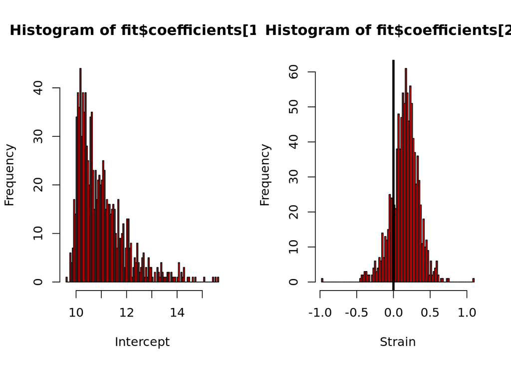

```r
par(mfrow=c(1,2))
hist(fit$coefficients[1,],breaks=100,col=2,xlab="Intercept")
hist(fit$coefficients[2,],breaks=100,col=2,xlab="Strain")
abline(v=0,lwd=3,col=1)
```

### Look at the residuals for a couple of genes

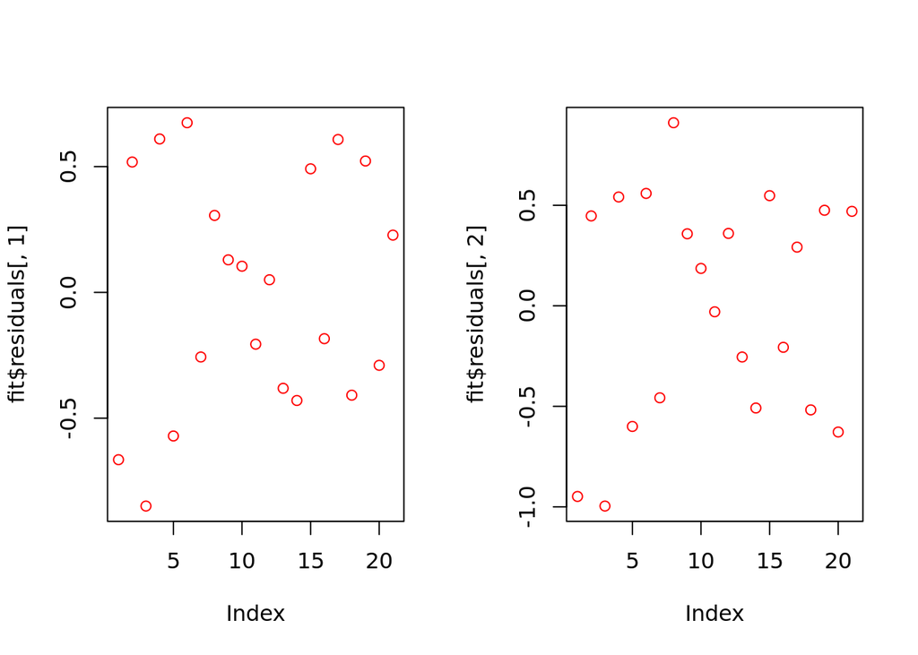

```r
par(mfrow=c(1,2))
plot(fit$residuals[,1],col=2)
plot(fit$residuals[,2],col=2)
```

### Fit many regressions with an adjustment

```r
mod_adj = model.matrix(~ pdata$strain + as.factor(pdata$lane.number))
fit_adj = lm.fit(mod_adj,t(edata))
fit_adj$coefficients[,1]
```

```
##                   (Intercept)            pdata$strainDBA/2J
##                   10.31359781                    0.28934825
## as.factor(pdata$lane.number)2 as.factor(pdata$lane.number)3
##                    0.05451431                    0.02502244
## as.factor(pdata$lane.number)5 as.factor(pdata$lane.number)6
##                    0.07200502                    0.38038016
## as.factor(pdata$lane.number)7 as.factor(pdata$lane.number)8
##                    0.21815863                    0.15103858
```

## Fit many regressions with the limma package

```r
fit_limma = lmFit(edata,mod_adj)
names(fit_limma)
```

```
##  [1] "coefficients"     "rank"             "assign"
##  [4] "qr"               "df.residual"      "sigma"
##  [7] "cov.coefficients" "stdev.unscaled"   "pivot"
## [10] "Amean"            "method"           "design"
```

```r
fit_limma$coefficients[1,]
```

```
##                   (Intercept)            pdata$strainDBA/2J
##                   10.31359781                    0.28934825
## as.factor(pdata$lane.number)2 as.factor(pdata$lane.number)3
##                    0.05451431                    0.02502244
## as.factor(pdata$lane.number)5 as.factor(pdata$lane.number)6
##                    0.07200502                    0.38038016
## as.factor(pdata$lane.number)7 as.factor(pdata$lane.number)8
##                    0.21815863                    0.15103858
```

```r
fit_adj$coefficients[,1]
```

```
##                   (Intercept)            pdata$strainDBA/2J
##                   10.31359781                    0.28934825
## as.factor(pdata$lane.number)2 as.factor(pdata$lane.number)3
##                    0.05451431                    0.02502244
## as.factor(pdata$lane.number)5 as.factor(pdata$lane.number)6
##                    0.07200502                    0.38038016
## as.factor(pdata$lane.number)7 as.factor(pdata$lane.number)8
##                    0.21815863                    0.15103858
```

## Calculate t- or F-statistics rapidly

The `genefilter` package lets you compute statistics rapidly for very simple cases (two or multi-group) comparisons. These are not moderated in any way.

```r
tstats_obj = rowttests(edata,pdata$strain)
names(tstats_obj)
```

```
## [1] "statistic" "dm"        "p.value"
```

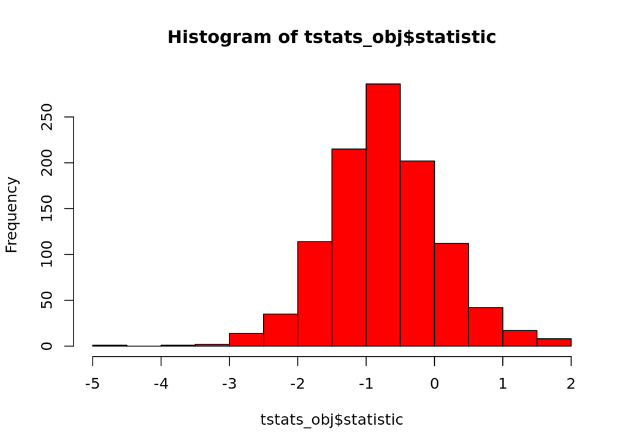

```r
hist(tstats_obj$statistic,col=2)
```

## Empirical Bayes adjustment

```r
ebayes_limma = eBayes(fit_limma)
head(ebayes_limma$t)
```

```
##                    (Intercept) pdata$strainDBA/2J
## ENSMUSG00000000131    27.42608        0.993341906
## ENSMUSG00000000149    28.30319       -0.302293604
## ENSMUSG00000000374    28.43334        0.684161612
## ENSMUSG00000000399    26.89729       -0.007509614
## ENSMUSG00000000532    29.20894        0.552296098
## ENSMUSG00000000605    30.52908        0.450401742
##                    as.factor(pdata$lane.number)2
## ENSMUSG00000000131                   0.106103723
## ENSMUSG00000000149                   0.283169296
## ENSMUSG00000000374                   0.062660205
## ENSMUSG00000000399                   0.066998156
## ENSMUSG00000000532                  -0.036205851
## ENSMUSG00000000605                   0.001102388
##                    as.factor(pdata$lane.number)3
## ENSMUSG00000000131                    0.04870234
## ENSMUSG00000000149                    0.15268674
## ENSMUSG00000000374                   -0.04788353
## ENSMUSG00000000399                   -0.13957244
## ENSMUSG00000000532                   -0.13080316
## ENSMUSG00000000605                   -0.08760933
##                    as.factor(pdata$lane.number)5
## ENSMUSG00000000131                   0.137709189
## ENSMUSG00000000149                   0.114049004
## ENSMUSG00000000374                  -0.031272733
## ENSMUSG00000000399                   0.156240669
## ENSMUSG00000000532                  -0.007169364
## ENSMUSG00000000605                   0.185393375
##                    as.factor(pdata$lane.number)6
## ENSMUSG00000000131                     0.7274749
## ENSMUSG00000000149                     1.0154366
## ENSMUSG00000000374                     0.5228153
## ENSMUSG00000000399                     0.8271336
## ENSMUSG00000000532                     0.3135213
## ENSMUSG00000000605                     0.4940291
##                    as.factor(pdata$lane.number)7
## ENSMUSG00000000131                    0.41722714
## ENSMUSG00000000149                    0.58175790
## ENSMUSG00000000374                    0.23222225
## ENSMUSG00000000399                    0.05475727
## ENSMUSG00000000532                    0.14890971
## ENSMUSG00000000605                    0.27370736
##                    as.factor(pdata$lane.number)8
## ENSMUSG00000000131                    0.28886043
## ENSMUSG00000000149                    0.39833581
## ENSMUSG00000000374                    0.11020429
## ENSMUSG00000000399                   -0.01182217
## ENSMUSG00000000532                   -0.02978295
## ENSMUSG00000000605                    0.18942807
```

If the model is unadjusted you get the moderated version of the t-statistic

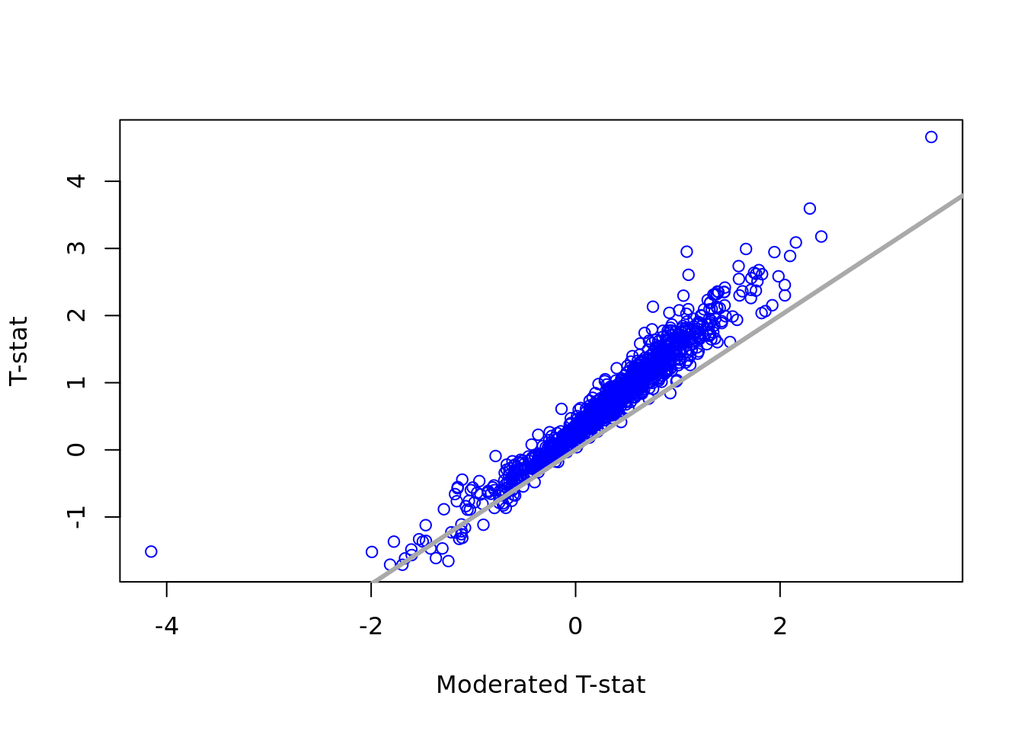

```r
plot(ebayes_limma$t[,2],-tstats_obj$statistic,col=4,
     xlab="Moderated T-stat",ylab="T-stat")
abline(c(0,1),col="darkgrey",lwd=3)
```

Sometimes we want to compare the null model to the alternative model with some additional covariates. Here we have to know which coefficients we want to test in the alternative model.

Suppose we wanted to find lane effects then we can fit a limma model and find which coefficients belong to the lane variable.

```r
mod_lane = model.matrix(~ as.factor(pdata$lane.number))
fit_limma_lane = lmFit(edata,mod_lane)
ebayes_limma_lane = eBayes(fit_limma_lane)
head(ebayes_limma_lane$t)
```

```
##                    (Intercept) as.factor(pdata$lane.number)2
## ENSMUSG00000000131    29.18101                   0.108054558
## ENSMUSG00000000149    29.75296                   0.288375678
## ENSMUSG00000000374    30.15864                   0.063812283
## ENSMUSG00000000399    28.35119                   0.068229991
## ENSMUSG00000000532    30.94034                  -0.036871536
## ENSMUSG00000000605    32.30420                   0.001122656
##                    as.factor(pdata$lane.number)3
## ENSMUSG00000000131                    0.04959779
## ENSMUSG00000000149                    0.15549405
## ENSMUSG00000000374                   -0.04876393
## ENSMUSG00000000399                   -0.14213864
## ENSMUSG00000000532                   -0.13320812
## ENSMUSG00000000605                   -0.08922013
##                    as.factor(pdata$lane.number)5
## ENSMUSG00000000131                    0.33389895
## ENSMUSG00000000149                    0.06002328
## ENSMUSG00000000374                    0.09926018
## ENSMUSG00000000399                    0.16048443
## ENSMUSG00000000532                    0.09886277
## ENSMUSG00000000605                    0.27882684
##                    as.factor(pdata$lane.number)6
## ENSMUSG00000000131                     0.9451392
## ENSMUSG00000000149                     0.9942322
## ENSMUSG00000000374                     0.6735237
## ENSMUSG00000000399                     0.8558060
## ENSMUSG00000000532                     0.4312304
## ENSMUSG00000000605                     0.5987006
##                    as.factor(pdata$lane.number)7
## ENSMUSG00000000131                    0.62359473
## ENSMUSG00000000149                    0.54476241
## ENSMUSG00000000374                    0.37234955
## ENSMUSG00000000399                    0.05530581
## ENSMUSG00000000532                    0.26062501
## ENSMUSG00000000605                    0.37035652
##                    as.factor(pdata$lane.number)8
## ENSMUSG00000000131                    0.49055391
## ENSMUSG00000000149                    0.35466155
## ENSMUSG00000000374                    0.24588867
## ENSMUSG00000000399                   -0.01369792
## ENSMUSG00000000532                    0.07542578
## ENSMUSG00000000605                    0.28300845
```

Then we can get the F-statistics with `topTable`

```r
top_lane = topTable(ebayes_limma_lane, coef=2:7,
                    number=dim(edata)[1],sort.by="none")
head(top_lane)
```

```
##                    as.factor.pdata.lane.number.2
## ENSMUSG00000000131                  0.0545143060
## ENSMUSG00000000149                  0.1454876148
## ENSMUSG00000000374                  0.0321937582
## ENSMUSG00000000399                  0.0344225239
## ENSMUSG00000000532                 -0.0186019566
## ENSMUSG00000000605                  0.0005663883
##                    as.factor.pdata.lane.number.3
## ENSMUSG00000000131                    0.02502244
## ENSMUSG00000000149                    0.07844787
## ENSMUSG00000000374                   -0.02460175
## ENSMUSG00000000399                   -0.07170997
## ENSMUSG00000000532                   -0.06720446
## ENSMUSG00000000605                   -0.04501220
##                    as.factor.pdata.lane.number.5
## ENSMUSG00000000131                    0.16845444
## ENSMUSG00000000149                    0.03028218
## ENSMUSG00000000374                    0.05007748
## ENSMUSG00000000399                    0.08096556
## ENSMUSG00000000532                    0.04987698
## ENSMUSG00000000605                    0.14067016
##                    as.factor.pdata.lane.number.6
## ENSMUSG00000000131                     0.4768296
## ENSMUSG00000000149                     0.5015973
## ENSMUSG00000000374                     0.3397976
## ENSMUSG00000000399                     0.4317603
## ENSMUSG00000000532                     0.2175589
## ENSMUSG00000000605                     0.3020488
##                    as.factor.pdata.lane.number.7
## ENSMUSG00000000131                    0.31460805
## ENSMUSG00000000149                    0.27483657
## ENSMUSG00000000374                    0.18785304
## ENSMUSG00000000399                    0.02790218
## ENSMUSG00000000532                    0.13148720
## ENSMUSG00000000605                    0.18684754
##                    as.factor.pdata.lane.number.8  AveExpr          F
## ENSMUSG00000000131                    0.24748800 10.59389 0.23962863
## ENSMUSG00000000149                    0.17892932 10.78688 0.23360430
## ENSMUSG00000000374                    0.12405261 10.86015 0.12886955
## ENSMUSG00000000399                   -0.00691070 10.18493 0.21598161
## ENSMUSG00000000532                    0.03805285 11.08784 0.07307893
## ENSMUSG00000000605                    0.14277981 11.62820 0.12134214
##                      P.Value adj.P.Val
## ENSMUSG00000000131 0.9635205 0.9998831
## ENSMUSG00000000149 0.9657594 0.9998831
## ENSMUSG00000000374 0.9927726 0.9998831
## ENSMUSG00000000399 0.9718839 0.9998831
## ENSMUSG00000000532 0.9985087 0.9998831
## ENSMUSG00000000605 0.9938655 0.9998831
```

## P-values and multiple testing

```r
limma_pvals = topTable(ebayes_limma,number=dim(edata)[1])$P.Value
```

```
## Removing intercept from test coefficients
```

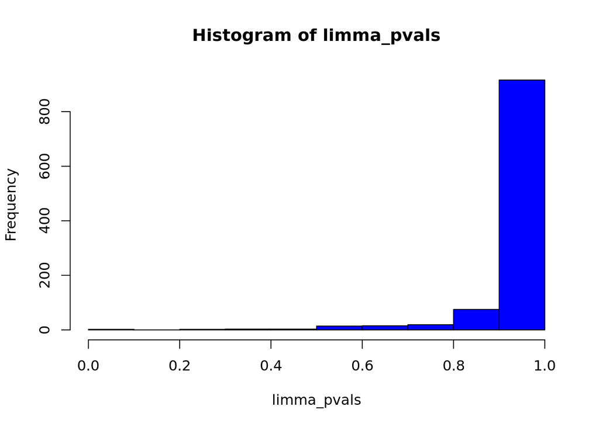

```r
hist(limma_pvals,col=4)
```

### Adjusted p-values from limma

```r
limma_pvals_adj = topTable(ebayes_limma,number=dim(edata)[1])$adj.P.Val
```

```
## Removing intercept from test coefficients
```

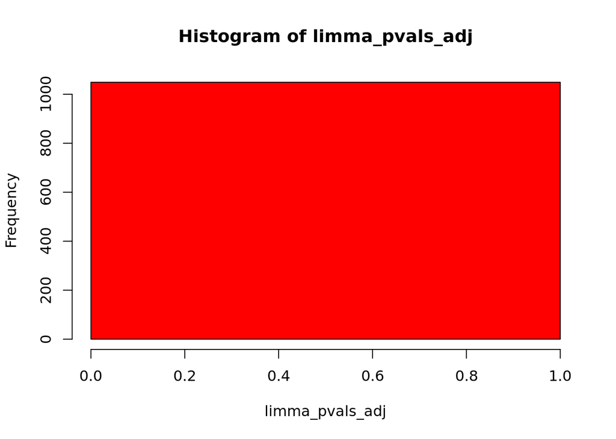

```r
hist(limma_pvals_adj,col=2)
```

```r
quantile(limma_pvals_adj)
```

```
##        0%       25%       50%       75%      100%
## 0.9998845 0.9998845 0.9998845 0.9998845 0.9998845
```

### Direct q-values

```r
qval_limma = qvalue(limma_pvals)
summary(qval_limma)
```

```
##
## Call:
## qvalue(p = limma_pvals)
##
## pi0: 1
##
## Cumulative number of significant calls:
##
##           <1e-04 <0.001 <0.01 <0.025 <0.05 <0.1   <1
## p-value        0      0     1      2     2    2 1049
## q-value        0      0     0      0     0    0 1049
## local FDR      0      0     0      0     0    0    0
```

```r
qval_limma$pi0
```

```
## [1] 1
```